# PL_simulation

Kristof Menyhert

2020 december 28

# Predicting the outcome of the English Premier League by using Monte Carlo Method

## Introduction

I have two hobbies: programming and making predictions. I also have some background in math, statistics and probability theory. These things also come handy since I use them at work as a data scientist.

I really like football and sometimes bet on matches. Nowadays bookmakers offer a lots of market, basically you can bet on nearly anything from who will be the next president of the USA to which county is going to win the next Eurovision song contest. But sport events are very popular when it comes to betting.

In this article I am going to show how I used Monte Carlo Method to predict the probabilities of each English Premier League clubs using R. What is cool that you can do it yourself by imputing your own predicions for each remaning mathes and by using the method and the script provided here you can do your own calculation and compare it with the actual odds.

If you trust yourself you can find value on the market and make money.

## Background - Understanding how betting works and what to look for

One concept that is essential to understand if you want to make money on the long run by betting on anything that you should look for value bets. What does this mean in practice? That you are looking for events that you think are misspriced, and you bet on an outcome where the real odds are in your favor.

Let me give you a small example, there is a football match today. Newcastle is playing against Liverpool. On [Betfair](https://www.betfair.com/exchange/plus/) - that operates the world’s largest online betting exchange - you can find the following odds:

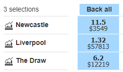

odds

We can convert these odds to probabilities by using the following formula: $\dfrac{1}{odds} \times 100 = probabily$. In this case the odds on the betting site reflexts the following probabilities for a Liverpool win: $\dfrac{1}{1.32} \times 100 = 75.8 \%$

So if you think that Liverpool has better chances to win than 75.8% than you should bet on this outcome, on the long run you are going to make money if you are right. However if you think that the chances are lower you can easily see that you should bet against them.

## The market of - The Winner of Englis Premier league 2020/21

As of today (2020.12.30.) on Betfair the odds are the following for the [winner of the PL](https://www.betfair.com/exchange/plus/football/market/1.171034359):

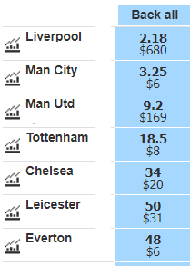

winner_odds

We would like to know that is this odds are in our favor or not? Should we bet on Liverpool or Man City or any other team? What would you do?

If you are interested there are other markets on Betfair as well when it comes to the final standings

## Okey, but what is Monte Carlo Method (MCM)?

I am not a mathematician so excuse me if I am not using the correct terms but this is how I would tell what MCM is in short:

Monte Carlo Method is commonly used for calculating the outcomes of non-deterministic processes where calculating the exact chances using formulas is hard or even impossible. Many times you can approach these problems in another way. You can simulate the results by drawing samples from a known probability distribution and then simulate the final outcome many many times. Then you can see the chances of occurrence for each outcomes.

Lets say that you would like to know what is the chance of rolling exactly 12 by rolling 5 dice. It would be possible to calculate this by using mathematical formulas but also you can simulate 1 million 5 dice rolls and check how many of those would be exactly 12. In this way you can approximate the chance by counting the favorable outcomes and divide it by 1 million. The more you simulate it will be much closer to the real probability. In this example case it will be very close since 1 million rolls is a lot.

Btw: you can use this method for many things, including approximating Pi. Learn more on the wikipedia side of [Monte Carlo Method](https://en.wikipedia.org/wiki/Monte_Carlo_method)

# Let’s start programing

In this tutorial I will try to explain how I did this simulation step by step. I used R since this is the most comfortable language to use for me.

## Load packages

For this purpose only 4-5 extra library is enough to use.

```r
library(data.table)
library(ggplot2)
library(stringr)
library(DT)
library(dplyr)
```

## The data that I have and what I prepared before

### Read in data

```r
pl_fix <- fread("../data/epl-2020.csv")
```

```r
datatable(pl_fix)
```

|  | Round Number | Date | Location | Home Team | Away Team | Result | notyetplayed | home_chance | draw_chance | away_chance | all_chance | home_odds | draw_odds | away_odds |
| --- | --- | --- | --- | --- | --- | --- | --- | --- | --- | --- | --- | --- | --- | --- |
| 1 | 1 | 12/9/2020 12:30 | Craven Cottage | Fulham | Arsenal | 0 - 3 |  |  |  |  | 0 |  |  |  |
| 2 | 1 | 12/9/2020 15:00 | Turf Moor | Burnley | Man Utd |  | x | 20 | 25 | 55 | 100 | 5 | 4 | 1.818181818 |
| 3 | 1 | 12/9/2020 15:00 | Etihad Stadium | Man City | Aston Villa |  | x | 65 | 25 | 10 | 100 | 1.538461538 | 4 | 10 |
| 4 | 1 | 12/9/2020 15:00 | Selhurst Park | Crystal Palace | Southampton | 1 - 0 |  |  |  |  | 0 |  |  |  |
| 5 | 1 | 12/9/2020 17:30 | Anfield | Liverpool | Leeds | 4 - 3 |  |  |  |  | 0 |  |  |  |
| 6 | 1 | 12/9/2020 20:00 | London Stadium | West Ham | Newcastle | 0 - 2 |  |  |  |  | 0 |  |  |  |
| 7 | 1 | 13/09/2020 14:00 | The Hawthorns | West Brom | Leicester | 0 - 3 |  |  |  |  | 0 |  |  |  |
| 8 | 1 | 13/09/2020 16:30 | Tottenham Hotspur Stadium | Spurs | Everton | 0 - 1 |  |  |  |  | 0 |  |  |  |
| 9 | 1 | 14/09/2020 18:00 | Bramall Lane | Sheffield Utd | Wolves | 0 - 2 |  |  |  |  | 0 |  |  |  |
| 10 | 1 | 14/09/2020 20:15 | Amex Stadium | Brighton | Chelsea | 1 - 3 |  |  |  |  | 0 |  |  |  |

[output cut: 370 more lines]

I have a .csv file with every Premier league matches including those which are already played and also those that have not played yet. Those that are not played yet are indicated with an ‘x’ in the ‘notyetplayed’ column and there are the chances of the outcomes for each match are written in the ‘home_chance’, ‘draw_chance’ and ‘away_chance’ column.

I imputed these probabilities based on what I think. Sadly it is not based on any model it just what I think of each match. So if you do not think as I think you can modify or estimate these chances by your own.

It is important to mention here that the Monte Carlo Simulation is using these probabilities to calculate the final chances so everyting is based on these chances.

```r
#pl_fix <- pl_fix[`Round Number` < 24]
#pl_fix <- pl_fix[notyetplayed != "x"]
```

```r
#london_clubs <- c("Arsenal", "Chelsea", "Crystal Palace", "West Ham", "Spurs", "Fulham")
#pl_fix <- pl_fix[`Home Team` %in% london_clubs & `Away Team` %in% london_clubs]
```

## Extract Result

We need to decide the winning team based on the result so I am extracting the numbers from the ‘Result’ column

```r
# put them into a new columns

pl_fix$result_home <- sub("-.*", "", pl_fix$Result)
pl_fix$result_away <- sub(".*-", "", pl_fix$Result)

convert_sting_to_result <- function(x){

  x <- str_replace_all(string = x, pattern=" ", repl="")
  x <- as.numeric(x)

  return(x)

}

pl_fix$result_home <- convert_sting_to_result(pl_fix$result_home)
pl_fix$result_away <- convert_sting_to_result(pl_fix$result_away)
```

## Indicate draw (d), home (h) and away (a) indicator

I am creating a new column that indicates which team won.

```r
pl_fix[, hda:= ifelse(result_home == result_away, "d", ifelse(result_home > result_away, "h", "a"))]
```

## Get team names

```r
team_names <- unique(c(pl_fix$`Home Team`, pl_fix$`Away Team`))

team_names
```

```
##  [1] "Fulham"         "Burnley"        "Man City"       "Crystal Palace"
##  [5] "Liverpool"      "West Ham"       "West Brom"      "Spurs"
##  [9] "Sheffield Utd"  "Brighton"       "Everton"        "Leeds"
## [13] "Man Utd"        "Arsenal"        "Southampton"    "Newcastle"
## [17] "Chelsea"        "Leicester"      "Aston Villa"    "Wolves"
```

```r
calculate_points <- function(pl_fix = pl_fix){

  round_table <- data.table(team = team_names, point = 0, matched_played = 0)

  for (row in c(1:nrow(pl_fix))){

    result <- pl_fix[row]$hda
    result <- as.character(result)

    home_team_name <- pl_fix[row]$`Home Team`
    home_team_matched_played <- max(round_table[team == home_team_name]$matched_played)
    home_team_point_before <- round_table[team == home_team_name & matched_played == home_team_matched_played]$point

    home_team_point <- ifelse(is.na(result), home_team_point_before + 0,
                              ifelse(result == "h", home_team_point_before + 3,
                                     ifelse(result == "d", home_team_point_before + 1,
                                            home_team_point_before + 0)))

    away_team_name <- pl_fix[row]$`Away Team`

    away_team_matched_played <- max(round_table[team == away_team_name]$matched_played)
    away_team_point_before <- round_table[team == away_team_name & matched_played == away_team_matched_played]$point

    away_team_point <- ifelse(is.na(result), away_team_point_before + 0,
                              ifelse(result == "a", away_team_point_before + 3,
                                     ifelse(result == "d", away_team_point_before + 1, away_team_point_before + 0)))

    round_table <-rbindlist(list(round_table, data.table(matched_played = home_team_matched_played + 1,
                                                         team = home_team_name,
                                                         point = home_team_point)),
                            fill = T)

    round_table <-rbindlist(list(round_table, data.table(matched_played = away_team_matched_played + 1,
                                                         team = away_team_name,
                                                         point = away_team_point)),
                            fill = T)

  }

  return(round_table)

}
```

```r
round_table <- calculate_points(pl_fix = pl_fix)
```

```r
show_standings <- function(round_table = round_table){

  standing_table <- round_table[, max_match:= max(matched_played, na.rm = T), by = team]
  standing_table <- standing_table[max_match == matched_played]
  standing_table <- standing_table[order(-point)]
  standing_table[, max_match:= NULL]

  return(standing_table)

}
```

```r
standing_table <- show_standings(round_table = round_table)
```

```r
standing_table
```

[output not shown]

# Simulation

## Write probabilities where it is not present

```r
pl_fix[notyetplayed == "" & hda == "h", home_chance:= 100]
pl_fix[notyetplayed == "" & hda == "h", draw_chance:= 0]
pl_fix[notyetplayed == "" & hda == "h", away_chance:= 0]

pl_fix[notyetplayed == "" & hda == "d", home_chance:= 0]
pl_fix[notyetplayed == "" & hda == "d", draw_chance:= 100]
pl_fix[notyetplayed == "" & hda == "d", away_chance:= 0]

pl_fix[notyetplayed == "" & hda == "a", home_chance:= 0]
pl_fix[notyetplayed == "" & hda == "a", draw_chance:= 0]
pl_fix[notyetplayed == "" & hda == "a", away_chance:= 100]
```

```r
sample(c("h", "d", "a"), size = 20, replace = TRUE, prob = c(0.8, 0.1, 0.1))
```

```
##  [1] "d" "a" "h" "h" "h" "a" "h" "h" "h" "h" "h" "h" "h" "a" "h" "h" "h" "h" "h"
## [20] "h"
```

```r
simulate_matches <- function(fixture_table = pl_fix, times = 10){

  output_table <- data.table()

  for (simulation_number in c(1:times)){

    for(row_number in c(1:nrow(fixture_table))){

    match_row <- fixture_table[row_number]

    outcome <- sample(c("h", "d", "a"),
                      size = 1,
                      replace = TRUE,
                      prob = c(match_row$home_chance, match_row$draw_chance, match_row$away_chance))

    match_row[, hda:= outcome]
    match_row[, simulation_id:= simulation_number]

    output_table <- rbindlist(list(output_table, match_row), fill = T)

    }

  }

  return(output_table)

}
```

```r
nr_simlation <- 10

simulated_matches_data <- simulate_matches(times = nr_simlation)
```

```r
simulate_standings <- function(all_matches = simulated_matches_data){

  standings_all <- data.table()

  for (fixtures in c(1:max(all_matches$simulation_id))){

    one_simulation <- all_matches[simulation_id == fixtures]

    simulated_fixtures <- calculate_points(one_simulation)
    simulated_fixtures[, simulation_id:= fixtures]

    standings_all <- rbindlist(list(standings_all, simulated_fixtures), fill = T)

  }

  return(standings_all)

}
```

```r
simulated_standings <- simulate_standings()
```

```r
last_round_standing <- simulated_standings[matched_played == 38]
last_round_standing <- last_round_standing[order(simulation_id, -point)]
last_round_standing[, standing:= c(1:.N), by = simulation_id]
```

```r
table(last_round_standing$team, last_round_standing$standing)
```

```
##
##                   1  2  3  4  5  6  7  8  9 10 11 12 13 14 15 16 17 18 19 20
##   Arsenal         0  0  0  0  0  0  4  0  1  1  2  1  0  0  1  0  0  0  0  0
##   Aston Villa     0  0  0  1  0  0  2  2  4  1  0  0  0  0  0  0  0  0  0  0
##   Brighton        0  0  0  0  0  0  0  0  0  0  0  0  1  0  0  2  3  4  0  0
##   Burnley         0  0  0  0  0  0  0  0  0  1  0  0  0  2  1  3  2  1  0  0
##   Chelsea         0  0  1  2  2  1  1  0  1  2  0  0  0  0  0  0  0  0  0  0
##   Crystal Palace  0  0  0  0  0  0  0  0  0  0  1  2  2  3  1  1  0  0  0  0
##   Everton         0  2  2  0  2  1  0  1  1  1  0  0  0  0  0  0  0  0  0  0
##   Fulham          0  0  0  0  0  0  0  0  0  0  0  0  0  0  0  0  4  3  3  0
##   Leeds           0  0  0  0  0  1  1  2  0  1  0  1  2  0  1  1  0  0  0  0
##   Leicester       1  0  1  2  2  3  1  0  0  0  0  0  0  0  0  0  0  0  0  0
##   Liverpool       6  4  0  0  0  0  0  0  0  0  0  0  0  0  0  0  0  0  0  0
##   Man City        3  3  2  2  0  0  0  0  0  0  0  0  0  0  0  0  0  0  0  0
##   Man Utd         0  1  4  2  1  0  1  1  0  0  0  0  0  0  0  0  0  0  0  0
##   Newcastle       0  0  0  0  0  0  0  1  0  0  0  3  0  4  0  2  0  0  0  0
##   Sheffield Utd   0  0  0  0  0  0  0  0  0  0  0  0  0  0  0  0  0  0  0 10
##   Southampton     0  0  0  0  0  1  0  0  2  0  2  2  1  0  1  1  0  0  0  0
##   Spurs           0  0  0  1  3  3  0  2  0  1  0  0  0  0  0  0  0  0  0  0
##   West Brom       0  0  0  0  0  0  0  0  0  0  0  0  0  0  1  0  1  2  6  0
##   West Ham        0  0  0  0  0  0  0  0  1  2  4  0  2  0  1  0  0  0  0  0
##   Wolves          0  0  0  0  0  0  0  1  0  0  1  1  2  1  3  0  0  0  1  0
```

```r
round(table(last_round_standing$team, last_round_standing$standing)/nr_simlation * 100, 1)
```

```
##
##                    1   2   3   4   5   6   7   8   9  10  11  12  13  14  15
##   Arsenal          0   0   0   0   0   0  40   0  10  10  20  10   0   0  10
##   Aston Villa      0   0   0  10   0   0  20  20  40  10   0   0   0   0   0
##   Brighton         0   0   0   0   0   0   0   0   0   0   0   0  10   0   0
##   Burnley          0   0   0   0   0   0   0   0   0  10   0   0   0  20  10
##   Chelsea          0   0  10  20  20  10  10   0  10  20   0   0   0   0   0
##   Crystal Palace   0   0   0   0   0   0   0   0   0   0  10  20  20  30  10
##   Everton          0  20  20   0  20  10   0  10  10  10   0   0   0   0   0
##   Fulham           0   0   0   0   0   0   0   0   0   0   0   0   0   0   0
##   Leeds            0   0   0   0   0  10  10  20   0  10   0  10  20   0  10
##   Leicester       10   0  10  20  20  30  10   0   0   0   0   0   0   0   0
##   Liverpool       60  40   0   0   0   0   0   0   0   0   0   0   0   0   0
##   Man City        30  30  20  20   0   0   0   0   0   0   0   0   0   0   0
##   Man Utd          0  10  40  20  10   0  10  10   0   0   0   0   0   0   0
##   Newcastle        0   0   0   0   0   0   0  10   0   0   0  30   0  40   0
##   Sheffield Utd    0   0   0   0   0   0   0   0   0   0   0   0   0   0   0
##   Southampton      0   0   0   0   0  10   0   0  20   0  20  20  10   0  10
##   Spurs            0   0   0  10  30  30   0  20   0  10   0   0   0   0   0
##   West Brom        0   0   0   0   0   0   0   0   0   0   0   0   0   0  10
##   West Ham         0   0   0   0   0   0   0   0  10  20  40   0  20   0  10
##   Wolves           0   0   0   0   0   0   0  10   0   0  10  10  20  10  30
##
##                   16  17  18  19  20
##   Arsenal          0   0   0   0   0
##   Aston Villa      0   0   0   0   0
##   Brighton        20  30  40   0   0
##   Burnley         30  20  10   0   0
##   Chelsea          0   0   0   0   0
##   Crystal Palace  10   0   0   0   0
##   Everton          0   0   0   0   0
##   Fulham           0  40  30  30   0
##   Leeds           10   0   0   0   0
##   Leicester        0   0   0   0   0
##   Liverpool        0   0   0   0   0
##   Man City         0   0   0   0   0
##   Man Utd          0   0   0   0   0
##   Newcastle       20   0   0   0   0
##   Sheffield Utd    0   0   0   0 100
##   Southampton     10   0   0   0   0
##   Spurs            0   0   0   0   0
##   West Brom        0  10  20  60   0
##   West Ham         0   0   0   0   0
##   Wolves           0   0   0  10   0
```

```r
1 / ((table(last_round_standing$team, last_round_standing$standing)/ nr_simlation))
```

```
##
##                          1         2         3         4         5         6
##   Arsenal              Inf       Inf       Inf       Inf       Inf       Inf
##   Aston Villa          Inf       Inf       Inf 10.000000       Inf       Inf
##   Brighton             Inf       Inf       Inf       Inf       Inf       Inf
##   Burnley              Inf       Inf       Inf       Inf       Inf       Inf
##   Chelsea              Inf       Inf 10.000000  5.000000  5.000000 10.000000
##   Crystal Palace       Inf       Inf       Inf       Inf       Inf       Inf
##   Everton              Inf  5.000000  5.000000       Inf  5.000000 10.000000
##   Fulham               Inf       Inf       Inf       Inf       Inf       Inf
##   Leeds                Inf       Inf       Inf       Inf       Inf 10.000000
##   Leicester      10.000000       Inf 10.000000  5.000000  5.000000  3.333333
##   Liverpool       1.666667  2.500000       Inf       Inf       Inf       Inf
##   Man City        3.333333  3.333333  5.000000  5.000000       Inf       Inf
##   Man Utd              Inf 10.000000  2.500000  5.000000 10.000000       Inf
##   Newcastle            Inf       Inf       Inf       Inf       Inf       Inf
##   Sheffield Utd        Inf       Inf       Inf       Inf       Inf       Inf
##   Southampton          Inf       Inf       Inf       Inf       Inf 10.000000
##   Spurs                Inf       Inf       Inf 10.000000  3.333333  3.333333
##   West Brom            Inf       Inf       Inf       Inf       Inf       Inf
##   West Ham             Inf       Inf       Inf       Inf       Inf       Inf
##   Wolves               Inf       Inf       Inf       Inf       Inf       Inf
##
##                          7         8         9        10        11        12
##   Arsenal         2.500000       Inf 10.000000 10.000000  5.000000 10.000000
##   Aston Villa     5.000000  5.000000  2.500000 10.000000       Inf       Inf
##   Brighton             Inf       Inf       Inf       Inf       Inf       Inf
##   Burnley              Inf       Inf       Inf 10.000000       Inf       Inf
##   Chelsea        10.000000       Inf 10.000000  5.000000       Inf       Inf
##   Crystal Palace       Inf       Inf       Inf       Inf 10.000000  5.000000
##   Everton              Inf 10.000000 10.000000 10.000000       Inf       Inf
##   Fulham               Inf       Inf       Inf       Inf       Inf       Inf
##   Leeds          10.000000  5.000000       Inf 10.000000       Inf 10.000000
##   Leicester      10.000000       Inf       Inf       Inf       Inf       Inf
##   Liverpool            Inf       Inf       Inf       Inf       Inf       Inf
##   Man City             Inf       Inf       Inf       Inf       Inf       Inf
##   Man Utd        10.000000 10.000000       Inf       Inf       Inf       Inf
##   Newcastle            Inf 10.000000       Inf       Inf       Inf  3.333333
##   Sheffield Utd        Inf       Inf       Inf       Inf       Inf       Inf
##   Southampton          Inf       Inf  5.000000       Inf  5.000000  5.000000
```

[output cut: 33 more lines]

```
##   Crystal Palace       Inf       Inf
##   Everton              Inf       Inf
##   Fulham          3.333333       Inf
##   Leeds                Inf       Inf
##   Leicester            Inf       Inf
##   Liverpool            Inf       Inf
##   Man City             Inf       Inf
##   Man Utd              Inf       Inf
##   Newcastle            Inf       Inf
##   Sheffield Utd        Inf  1.000000
##   Southampton          Inf       Inf
##   Spurs                Inf       Inf
##   West Brom       1.666667       Inf
##   West Ham             Inf       Inf
##   Wolves         10.000000       Inf
```

## Handicap

```r
handicap_point <- fread("C:/Users/x004896/OneDrive - Audax/fogadas_simulation/data/handicap.csv")

handicap_standing <- merge(simulated_standings, handicap_point, by.x = "team", by.y = "team_name", all.x = T)
handicap_standing[, point_hc:= point + handicap]
```

```r
last_round_standing_hc <- handicap_standing[matched_played == 38]
last_round_standing_hc <- last_round_standing_hc[order(simulation_id, -point_hc)]
last_round_standing_hc[, standing:= c(1:.N), by = simulation_id]
```

```r
round(table(last_round_standing_hc$team, last_round_standing_hc$standing)/nr_simlation * 100, 1)
```

```
##
##                    1   2   3   4   5   6   7   8   9  10  11  12  13  14  15
##   Arsenal          0   0   0   0   0   0   0   0   0  20  20   0   0   0   0
##   Aston Villa     80  20   0   0   0   0   0   0   0   0   0   0   0   0   0
##   Brighton         0   0   0   0   0   0   0   0  10   0   0   0  30  10   0
##   Burnley          0   0  10  10   0  10   0  10   0   0  10  20  10  20   0
##   Chelsea          0   0   0   0   0   0   0   0   0  10   0   0  10  10  10
##   Crystal Palace   0  10  20  10  20  10  20   0   0   0   0   0  10   0   0
##   Everton         20  40  10  10   0   0  10   0   0   0   0  10   0   0   0
##   Fulham           0   0   0   0   0   0  20  10   0   0  20  30   0   0  10
##   Leeds            0  10  10  30   0  10   0  20   0   0  10   0   0   0  10
##   Leicester        0  20   0  10  50  10   0   0   0   0   0   0   0  10   0
##   Liverpool        0   0   0   0   0  10  10   0  20   0  10   0  10   0  20
##   Man City         0   0   0   0   0   0   0  10   0   0   0  10  10   0   0
##   Man Utd          0   0   0   0   0  10   0   0  10  10  10  20  20   0  10
##   Newcastle        0   0  20  20  10  10  10  10   0  20   0   0   0   0   0
##   Sheffield Utd    0   0   0   0   0   0   0   0   0   0   0   0   0   0   0
##   Southampton      0   0  10   0   0  10   0  10  30   0  10  10   0  10   0
##   Spurs            0   0  10   0   0   0  20  20  10  20  10   0   0   0   0
##   West Brom        0   0   0   0   0   0   0   0  10  10   0   0   0  30  20
##   West Ham         0   0  10  10  20  20  10  10  10  10   0   0   0   0   0
##   Wolves           0   0   0   0   0   0   0   0   0   0   0   0   0  10  20
##
##                   16  17  18  19  20
##   Arsenal         20  10  20  10   0
##   Aston Villa      0   0   0   0   0
##   Brighton        10  10  20  10   0
##   Burnley          0   0   0   0   0
##   Chelsea          0  20  10  30   0
##   Crystal Palace   0   0   0   0   0
##   Everton          0   0   0   0   0
##   Fulham           0   0   0  10   0
##   Leeds            0   0   0   0   0
##   Leicester        0   0   0   0   0
##   Liverpool       10   0   0  10   0
##   Man City        10  20  20  20   0
##   Man Utd          0   0  10   0   0
##   Newcastle        0   0   0   0   0
##   Sheffield Utd    0   0   0   0 100
##   Southampton     10   0   0   0   0
##   Spurs            0  10   0   0   0
##   West Brom       10  10  10   0   0
##   West Ham         0   0   0   0   0
##   Wolves          30  20  10  10   0
```

```r
1 / ((table(last_round_standing_hc$team, last_round_standing_hc$standing)/nr_simlation))
```

```
##
##                          1         2         3         4         5         6
##   Arsenal              Inf       Inf       Inf       Inf       Inf       Inf
##   Aston Villa     1.250000  5.000000       Inf       Inf       Inf       Inf
##   Brighton             Inf       Inf       Inf       Inf       Inf       Inf
##   Burnley              Inf       Inf 10.000000 10.000000       Inf 10.000000
##   Chelsea              Inf       Inf       Inf       Inf       Inf       Inf
##   Crystal Palace       Inf 10.000000  5.000000 10.000000  5.000000 10.000000
##   Everton         5.000000  2.500000 10.000000 10.000000       Inf       Inf
##   Fulham               Inf       Inf       Inf       Inf       Inf       Inf
##   Leeds                Inf 10.000000 10.000000  3.333333       Inf 10.000000
##   Leicester            Inf  5.000000       Inf 10.000000  2.000000 10.000000
##   Liverpool            Inf       Inf       Inf       Inf       Inf 10.000000
##   Man City             Inf       Inf       Inf       Inf       Inf       Inf
##   Man Utd              Inf       Inf       Inf       Inf       Inf 10.000000
##   Newcastle            Inf       Inf  5.000000  5.000000 10.000000 10.000000
##   Sheffield Utd        Inf       Inf       Inf       Inf       Inf       Inf
##   Southampton          Inf       Inf 10.000000       Inf       Inf 10.000000
##   Spurs                Inf       Inf 10.000000       Inf       Inf       Inf
##   West Brom            Inf       Inf       Inf       Inf       Inf       Inf
##   West Ham             Inf       Inf 10.000000 10.000000  5.000000  5.000000
##   Wolves               Inf       Inf       Inf       Inf       Inf       Inf
##
##                          7         8         9        10        11        12
##   Arsenal              Inf       Inf       Inf  5.000000  5.000000       Inf
##   Aston Villa          Inf       Inf       Inf       Inf       Inf       Inf
##   Brighton             Inf       Inf 10.000000       Inf       Inf       Inf
##   Burnley              Inf 10.000000       Inf       Inf 10.000000  5.000000
##   Chelsea              Inf       Inf       Inf 10.000000       Inf       Inf
##   Crystal Palace  5.000000       Inf       Inf       Inf       Inf       Inf
##   Everton        10.000000       Inf       Inf       Inf       Inf 10.000000
##   Fulham          5.000000 10.000000       Inf       Inf  5.000000  3.333333
##   Leeds                Inf  5.000000       Inf       Inf 10.000000       Inf
##   Leicester            Inf       Inf       Inf       Inf       Inf       Inf
##   Liverpool      10.000000       Inf  5.000000       Inf 10.000000       Inf
##   Man City             Inf 10.000000       Inf       Inf       Inf 10.000000
##   Man Utd              Inf       Inf 10.000000 10.000000 10.000000  5.000000
##   Newcastle      10.000000 10.000000       Inf  5.000000       Inf       Inf
##   Sheffield Utd        Inf       Inf       Inf       Inf       Inf       Inf
##   Southampton          Inf 10.000000  3.333333       Inf 10.000000 10.000000
```

[output cut: 33 more lines]

```
##   Crystal Palace       Inf       Inf
##   Everton              Inf       Inf
##   Fulham         10.000000       Inf
##   Leeds                Inf       Inf
##   Leicester            Inf       Inf
##   Liverpool      10.000000       Inf
##   Man City        5.000000       Inf
##   Man Utd              Inf       Inf
##   Newcastle            Inf       Inf
##   Sheffield Utd        Inf  1.000000
##   Southampton          Inf       Inf
##   Spurs                Inf       Inf
##   West Brom            Inf       Inf
##   West Ham             Inf       Inf
##   Wolves         10.000000       Inf
```